# vehicle sillhoute (5) (2) (2) - Jupyter Notebook

#### 1.2.c:Training set of 100

```
xxxxxxxxxx
```

```
# Set a fixed random seed for reproducibility
```

```
set.seed(234)
```

```
# Randomly sample row indices for the training set
```

```
train_indices <- sample(1:nrow(dataset), 100)
```

```
# Create the training set by selecting rows based on the sampled indices
```

```
Vehicle.train <- dataset[train_indices, ]
```

```
# Create the testing set by excluding rows from the training set
```

```
Vehicle.test <- dataset[-train_indices, ]
```

```
# Extract the target variable for the testing set
```

```
class.test <- dataset$class[-train_indices]
```

```
# Fit a classification tree to your Vehicle Silhouettes dataset
```

```
fit.tree <- rpart(Class ~ ., data = Vehicle.train, method = "class", cp = 0.008)
```

```
# Print the fitted tree(flag)
```

```
fit.tree
```

```
xxxxxxxxxx
```

```
<pre>n= 100
```

```
node), split, n, loss, yval, (yprob)
```

```
      * denotes terminal node
```

```
1) root 100 60 1 (0.40000000 0.37000000 0.23000000)
```

```
  2) max.length_aspect_ratio< 8.5 55 15 1 (0.72727273 0.20000000 0.07272727)
```

```
    4) scatter_ratio>=141.5 44  4 1 (0.90909091 0.09090909 0.00000000) *
```

```
    5) scatter_ratio< 141.5 11  4 2 (0.00000000 0.63636364 0.36363636) *
```

```
  3) max.length_aspect_ratio>=8.5 45 19 2 (0.00000000 0.57777778 0.42222222)
```

```
    6) elongatedness< 41.5 25  0 2 (0.00000000 1.00000000 0.00000000) *
```

```
    7) elongatedness>=41.5 20  1 3 (0.00000000 0.05000000 0.95000000) *</pre>
```

```
n= 100

node), split, n, loss, yval, (yprob)
      * denotes terminal node

1) root 100 60 1 (0.40000000 0.37000000 0.23000000)
  2) max.length_aspect_ratio< 8.5 55 15 1 (0.72727273 0.20000000 0.07272727)
    4) scatter_ratio>=141.5 44  4 1 (0.90909091 0.09090909 0.00000000) *
    5) scatter_ratio< 141.5 11  4 2 (0.00000000 0.63636364 0.36363636) *
  3) max.length_aspect_ratio>=8.5 45 19 2 (0.00000000 0.57777778 0.42222222)
    6) elongatedness< 41.5 25  0 2 (0.00000000 1.00000000 0.00000000) *
    7) elongatedness>=41.5 20  1 3 (0.00000000 0.05000000 0.95000000) *
```

```
xxxxxxxxxx
```

[output not shown]

[output not shown]

```
For instances where "max.length_aspect_ratio" is equal to or greater than 8.5, the tree considers the "elongatedness" feature. If "elongatedness" is less than 41.5, 25 instances are accurately classified as class 2, demonstrating a 100% accuracy for this condition. On the other hand, if "elongatedness" is 41.5 or greater, the model correctly identifies 95% of instances as class 3 (bus)
```

For instances where "max.length_aspect_ratio" is equal to or greater than 8.5, the tree considers the "elongatedness" feature. If "elongatedness" is less than 41.5, 25 instances are accurately classified as class 2, demonstrating a 100% accuracy for this condition. On the other hand, if "elongatedness" is 41.5 or greater, the model correctly identifies 95% of instances as class 3 (bus)

```
xxxxxxxxxx
```

```
#Visualize the Classification Tree
```

```
install.packages("rpart.plot")
```

```
library(rpart.plot)
```

```
rpart.plot(fit.tree)
```

```
xxxxxxxxxx
```

```
![lena3.png](attachment:lena3.png)
```

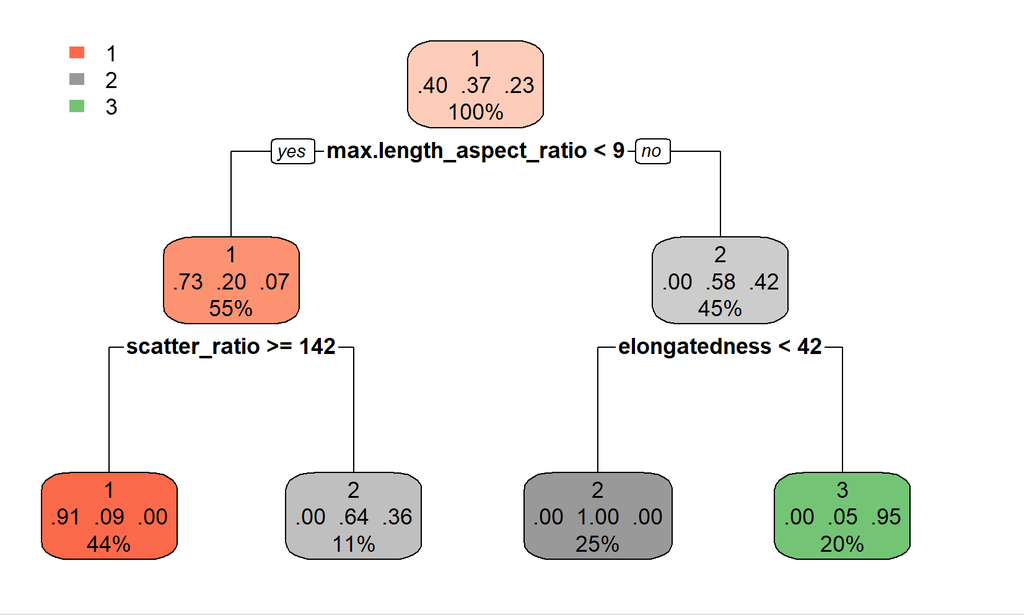

```
xxxxxxxxxx
```

[output not shown]

```
For instances where "max.length_aspect_ratio" is less than 8.5, the majority (55 out of 100) of the dataset is directed to this branch. Further differentiation occurs based on the "scatter_ratio" variable. Impressively, when "scatter_ratio" is 141.5 or higher, the model accurately identifies 90.91% of instances as class 1 (cars). Conversely, when "scatter_ratio" is below 141.5, the model shows a strong capability of recognizing 63.64% of instances as class 2 (vans).
```

```
On the other hand, for instances where "max.length_aspect_ratio" is equal to or greater than 8.5, the tree considers the "elongatedness" feature. If "elongatedness" is less than 41.5, the model achieves a perfect classification (100% accuracy) for class 2 (vans). However, if "elongatedness" is 41.5 or greater, the model effectively identifies 95% of instances as class 3 (buses).
```

For instances where "max.length_aspect_ratio" is less than 8.5, the majority (55 out of 100) of the dataset is directed to this branch. Further differentiation occurs based on the "scatter_ratio" variable. Impressively, when "scatter_ratio" is 141.5 or higher, the model accurately identifies 90.91% of instances as class 1 (cars). Conversely, when "scatter_ratio" is below 141.5, the model shows a strong capability of recognizing 63.64% of instances as class 2 (vans).

On the other hand, for instances where "max.length_aspect_ratio" is equal to or greater than 8.5, the tree considers the "elongatedness" feature. If "elongatedness" is less than 41.5, the model achieves a perfect classification (100% accuracy) for class 2 (vans). However, if "elongatedness" is 41.5 or greater, the model effectively identifies 95% of instances as class 3 (buses).

```
xxxxxxxxxx
```

```
# Checking the order of variable importance
```

```
fit.tree$variable.importance
```

```
xxxxxxxxxx
```

```
<pre>  scatter_ratio             elongatedness         scaled_variance.1
```

```
                37.092661                 31.110101                 31.110101
```

```
          scaled_variance      distance_circularity   max.length_aspect_ratio
```

```
                29.102365                 28.528007                 19.646263
```

```
             radius_ratio               circularity max.length_rectangularity
```

```
                18.050000                 16.202967                 10.478007
```

```
            hollows_ratio scaled_radius_of_gyration
```

```
                 9.168256                  7.034711 </pre>
```

```
  scatter_ratio             elongatedness         scaled_variance.1
                37.092661                 31.110101                 31.110101
          scaled_variance      distance_circularity   max.length_aspect_ratio
                29.102365                 28.528007                 19.646263
             radius_ratio               circularity max.length_rectangularity
                18.050000                 16.202967                 10.478007
            hollows_ratio scaled_radius_of_gyration
                 9.168256                  7.034711
```

```
xxxxxxxxxx
```

```
The top three influential features are "scatter_ratio," "elongatedness," and "scaled_variance.1," with variable importance scores of 37.09, 31.11, and 31.11, respectively.
```

```
"Scatter_ratio" emerges as the most crucial factor, indicating that the spread of points in the silhouette plays a significant role in distinguishing between vehicle classes. Following closely, "elongatedness" suggests that the elongation of the vehicle silhouette is an important discriminant, aligning with expectations as different vehicle types exhibit distinct elongation patterns. Similarly, "scaled_variance.1," a measure of the variance of the standardized projection onto the first principal component, underscores the importance of silhouette variability in the classification process.
```

```
The next set of features, such as "scaled_variance," "distance_circularity," and "max.length_aspect_ratio," also contribute to the decision-making, although to a slightly lesser extent. Understanding the relative importance of these features guides further investigation and potential refinement of the model.
```

The top three influential features are "scatter_ratio," "elongatedness," and "scaled_variance.1," with variable importance scores of 37.09, 31.11, and 31.11, respectively.

"Scatter_ratio" emerges as the most crucial factor, indicating that the spread of points in the silhouette plays a significant role in distinguishing between vehicle classes. Following closely, "elongatedness" suggests that the elongation of the vehicle silhouette is an important discriminant, aligning with expectations as different vehicle types exhibit distinct elongation patterns. Similarly, "scaled_variance.1," a measure of the variance of the standardized projection onto the first principal component, underscores the importance of silhouette variability in the classification process.

The next set of features, such as "scaled_variance," "distance_circularity," and "max.length_aspect_ratio," also contribute to the decision-making, although to a slightly lesser extent. Understanding the relative importance of these features guides further investigation and potential refinement of the model.

```
xxxxxxxxxx
```

```
#Predict Using the Classification Tree
```

```
pred.tree <- predict(fit.tree, Vehicle.test, type = "class")
```

```
# Evaluate the performance of the classification tree
```

```
confusion_matrix <- table(pred.tree, Vehicle.test$Class)
```

```
# Print or inspect the confusion matrix
```

```
print(confusion_matrix)
```

```
xxxxxxxxxx
```

```
<pre>pred.tree   1   2   3
```

```
        1 156  48   8
```

```
        2   1 110  81
```

```
        3   2   4  87</pre>
```

```
pred.tree   1   2   3
        1 156  48   8
        2   1 110  81
        3   2   4  87
```

```
xxxxxxxxxx
```

```
In the presented matrix, the rows represent the predicted classes (1, 2, 3), while the columns represent the true classes.
```

```
Upon analysis, the diagonal elements represent correctly classified instances for each class. For instance, the value of 156 in the (1, 1) position indicates that 156 instances of class 1 were correctly predicted. Similarly, values of 110 and 87 in the (2, 2) and (3, 3) positions indicate correct predictions for classes 2 and 3, respectively.
```

[output not shown]

In the presented matrix, the rows represent the predicted classes (1, 2, 3), while the columns represent the true classes.

Upon analysis, the diagonal elements represent correctly classified instances for each class. For instance, the value of 156 in the (1, 1) position indicates that 156 instances of class 1 were correctly predicted. Similarly, values of 110 and 87 in the (2, 2) and (3, 3) positions indicate correct predictions for classes 2 and 3, respectively.

```
xxxxxxxxxx
```

```
#plotcp(fit.tree)
```

```
printcp(fit.tree)
```

```
xxxxxxxxxx
```

```
<pre>Classification tree:
```

```
rpart(formula = Class ~ ., data = Vehicle.train, method = "class",
```

```
    cp = 0.008)
```

```
Variables actually used in tree construction:
```

```
[1] elongatedness           max.length_aspect_ratio scatter_ratio
```

```
Root node error: 60/100 = 0.6
```

```
n= 100
```

```
       CP nsplit rel error  xerror     xstd
```

```
1 0.43333      0   1.00000 1.00000 0.081650
```

```
2 0.30000      1   0.56667 0.56667 0.078951
```

```
3 0.11667      2   0.26667 0.30000 0.064031
```

```
4 0.00800      3   0.15000 0.18333 0.052148</pre>
```

```
Classification tree:
rpart(formula = Class ~ ., data = Vehicle.train, method = "class",
    cp = 0.008)

Variables actually used in tree construction:
[1] elongatedness           max.length_aspect_ratio scatter_ratio

Root node error: 60/100 = 0.6

n= 100

       CP nsplit rel error  xerror     xstd
1 0.43333      0   1.00000 1.00000 0.081650
2 0.30000      1   0.56667 0.56667 0.078951
3 0.11667      2   0.26667 0.30000 0.064031
4 0.00800      3   0.15000 0.18333 0.052148
```

```
xxxxxxxxxx
```

```
he classification tree was initially constructed with a relatively small cp value of 0.008, indicating a more complex tree structure with finer splits. The tree construction used three predictor variables: elongatedness, max.length_aspect_ratio, and scatter_ratio.
```

[output not shown]

[output not shown]

he classification tree was initially constructed with a relatively small cp value of 0.008, indicating a more complex tree structure with finer splits. The tree construction used three predictor variables: elongatedness, max.length_aspect_ratio, and scatter_ratio.

```
xxxxxxxxxx
```

```
# Explicitly request the lowest cp value
```

```
fit.tree$cptable[which.min(fit.tree$cptable[,"xerror"]),"CP"]
```

```
#Applying the pruned tree, the tree with the lowest cp value
```

```
bestcp <-fit.tree$cptable[which.min(fit.tree$cptable[,"xerror"]),"CP"]
```

```
pruned.tree <- prune(fit.tree, cp = bestcp)
```

```
rpart.plot(pruned.tree)
```

```
xxxxxxxxxx
```

```
![lena32.png](attachment:lena32.png)
```

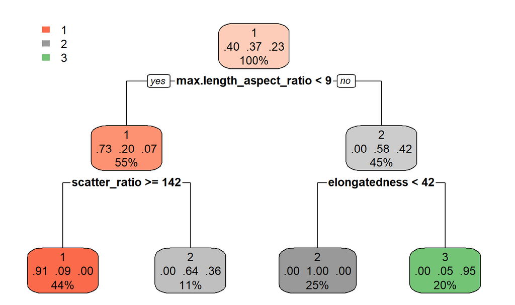

```
xxxxxxxxxx
```

```
This is the third iteration in which we applied the code to various sample sizes. Surprisingly, the structure of the fitted tree remains constant and does not alter even after pruning. The pruned tree, in fact, mirrors the original fitted tree before pruning, and both exhibit identical output values. This consistent pattern across multiple runs prompts us to investigate the underlying reasons for the remarkable stability observed in the data.
```

This is the third iteration in which we applied the code to various sample sizes. Surprisingly, the structure of the fitted tree remains constant and does not alter even after pruning. The pruned tree, in fact, mirrors the original fitted tree before pruning, and both exhibit identical output values. This consistent pattern across multiple runs prompts us to investigate the underlying reasons for the remarkable stability observed in the data.

```
xxxxxxxxxx
```

```
#Predict using the pruned tree on your test data
```

```
pred.prune <- predict(pruned.tree, Vehicle.test, type = "class")
```

```
# Evaluate the performance of the pruned tree
```

```
confusion_matrix <- table(pred.prune, Vehicle.test$Class)
```

```
# Print or inspect the confusion matrix
```

```
print(confusion_matrix)
```

```
xxxxxxxxxx
```

```
<pre>pred.prune   1   2   3
```

```
         1 156  48   8
```

```
         2   1 110  81
```

```
         3   2   4  87</pre>
```

```
pred.prune   1   2   3
         1 156  48   8
         2   1 110  81
         3   2   4  87
```

```
xxxxxxxxxx
```

[output not shown]

```
xxxxxxxxxx
```

```
#performance metrics
```

```
library(caret)
```

```
confusion_matrix_result <- confusionMatrix(pred.prune, Vehicle.test$Class)
```

```
confusion_matrix_result
```

```
xxxxxxxxxx
```

```
<pre>Confusion Matrix and Statistics
```

```
          Reference
```

```
Prediction   1   2   3
```

```
         1 156  48   8
```

```
         2   1 110  81
```

```
         3   2   4  87
```

```
Overall Statistics
```

```
               Accuracy : 0.7103
```

```
                 95% CI : (0.6682, 0.7498)
```

```
    No Information Rate : 0.3541
```

```
    P-Value [Acc > NIR] : < 2.2e-16>
```

```
                  Kappa : 0.5684
```

```
 Mcnemar's Test P-Value : < 2.2e-16>
```

```
Statistics by Class:
```

```
                     Class: 1 Class: 2 Class: 3
```

```
Sensitivity            0.9811   0.6790   0.4943
```

```
Specificity            0.8343   0.7552   0.9813
```

```
Pos Pred Value         0.7358   0.5729   0.9355
```

```
Neg Pred Value         0.9895   0.8295   0.7797
```

```
Prevalence             0.3199   0.3260   0.3541
```

```
Detection Rate         0.3139   0.2213   0.1751
```

```
Detection Prevalence   0.4266   0.3863   0.1871
```

```
        Balanced Accuracy      0.9077   0.7171   0.7378 </pre>
```

```
Confusion Matrix and Statistics

          Reference
Prediction   1   2   3
         1 156  48   8
         2   1 110  81
         3   2   4  87

Overall Statistics

               Accuracy : 0.7103
                 95% CI : (0.6682, 0.7498)
    No Information Rate : 0.3541
    P-Value [Acc > NIR] : < 2.2e-16>

                  Kappa : 0.5684

 Mcnemar's Test P-Value : < 2.2e-16>

Statistics by Class:

                     Class: 1 Class: 2 Class: 3
Sensitivity            0.9811   0.6790   0.4943
Specificity            0.8343   0.7552   0.9813
Pos Pred Value         0.7358   0.5729   0.9355
Neg Pred Value         0.9895   0.8295   0.7797
Prevalence             0.3199   0.3260   0.3541
Detection Rate         0.3139   0.2213   0.1751
Detection Prevalence   0.4266   0.3863   0.1871
        Balanced Accuracy      0.9077   0.7171   0.7378
```

```
xxxxxxxxxx
```

[output not shown]

```
xxxxxxxxxx
```

```
**In conclusion**, we employed the Gini index, a classification metric utilized to assess the impurity or homogeneity of our dataset within a decision tree algorithm. The Gini index was applied iteratively on our data with different training sample sizes (200, 500, 100). Remarkably, in each instance, the outcome remained consistent: the structure of the pruned decision tree mirrored exactly that of the original fitted tree, and both produced identical confusion matrices. Several factors might contribute to this observed stability. Randomness in Data Sampling emerges as a probable cause, given that the training set is randomly sampled, potentially limiting scenarios where pruning significantly alters the tree. Other potential explanations include the absence of Overfitting in the original tree, an optimal Complexity Parameter (cp) value, or an inherently simple tree structure that resists substantial reduction through pruning.
```

```
despite the lack of significant alterations through pruning, indicate that the original fitted trees were well-suited and exhibited robust performance before the Gini index was applied. This underscores the importance of careful consideration in selecting and pruning decision trees, acknowledging the nuanced interplay of factors influencing their stability and performance.
```

**In conclusion**, we employed the Gini index, a classification metric utilized to assess the impurity or homogeneity of our dataset within a decision tree algorithm. The Gini index was applied iteratively on our data with different training sample sizes (200, 500, 100). Remarkably, in each instance, the outcome remained consistent: the structure of the pruned decision tree mirrored exactly that of the original fitted tree, and both produced identical confusion matrices. Several factors might contribute to this observed stability. Randomness in Data Sampling emerges as a probable cause, given that the training set is randomly sampled, potentially limiting scenarios where pruning significantly alters the tree. Other potential explanations include the absence of Overfitting in the original tree, an optimal Complexity Parameter (cp) value, or an inherently simple tree structure that resists substantial reduction through pruning. despite the lack of significant alterations through pruning, indicate that the original fitted trees were well-suited and exhibited robust performance before the Gini index was applied. This underscores the importance of careful consideration in selecting and pruning decision trees, acknowledging the nuanced interplay of factors influencing their stability and performance.

```
xxxxxxxxxx
```

```
<h3>1.3:Gain ratio</h3>
```

### 1.3:Gain ratio

```
xxxxxxxxxx
```

```
The gain ratio is determined by dividing the information gain by the intrinsic information. This calculation aims to strike a balance between achieving substantial information gain and favoring simpler tree structures.
```

The gain ratio is determined by dividing the information gain by the intrinsic information. This calculation aims to strike a balance between achieving substantial information gain and favoring simpler tree structures.

```
xxxxxxxxxx
```

```
library(rpart.plot)
```

```
library(rpart)
```

```
library(RWeka)
```

```
library(caret)
```

```
library(C50)
```

```
##First lets read the csv
```

```
dataset<-read.csv('vehicle.csv')
```

```
databeforereprossess<-read.csv('vehicle.csv')
```

```
dataset$class <- factor(dataset$class, levels = c("bus", "car","van"), labels = c("1", "2","3"))
```

```
# Removing rows with any missing values
```

```
dataset <- na.omit(dataset)
```

```
# Create a new dataset without missing values
```

```
dataset_complete <- dataset[complete.cases(dataset), ]
```

```
set.seed(1958)  # set a seed to get replicable results
```

```
train <- createFolds(dataset$class, k=10)
```

```
C45Fit <- train(class ~., method="J48", data=dataset,
```

```
                tuneLength = 5,
```

```
                trControl = trainControl(
```

```
                  method="cv", indexOut=train))
```

```
C45Fit
```

```
C45Fit$finalModel
```

```
xxxxxxxxxx
```

```
<pre>C4.5-like Trees
```

```
813 samples
```

```
 18 predictor
```

```
  3 classes: '1', '2', '3'
```

```
No pre-processing
```

```
Resampling: Cross-Validated (10 fold)
```

```
Summary of sample sizes: 730, 733, 733, 731, 731, 733, ...
```

```
Resampling results across tuning parameters:
```

```
 C       M  Accuracy   Kappa
```

```
  0.0100  1  0.9606094  0.9370552
```

```
  0.0100  2  0.9532314  0.9254324
```

```
  0.0100  3  0.9422705  0.9081728
```

```
  0.0100  4  0.9446948  0.9116001
```

```
  0.0100  5  0.9446342  0.9112150
```

```
  0.1325  1  0.9802895  0.9683052
```

```
  0.1325  2  0.9655334  0.9447747
```

```
  0.1325  3  0.9557156  0.9289791
```

```
  0.1325  4  0.9496034  0.9190349
```

```
  0.1325  5  0.9483232  0.9169108
```

```
  0.2550  1  0.9815241  0.9702827
```

```
  0.2550  2  0.9691615  0.9505349
```

```
  0.2550  3  0.9557461  0.9290812
```

```
  0.2550  4  0.9508078  0.9207342
```

```
  0.2550  5  0.9471342  0.9148390
```

```
  0.3775  1  0.9790241  0.9662847
```

```
  0.3775  2  0.9679269  0.9485085
```

```
  0.3775  3  0.9545115  0.9270548
```

```
  0.3775  4  0.9495729  0.9188175
```

```
  0.3775  5  0.9483232  0.9166446
```

```
  0.5000  1  0.9790241  0.9662847
```

```
  0.5000  2  0.9691615  0.9505349
```

```
  0.5000  3  0.9557461  0.9290812
```

```
  0.5000  4  0.9495729  0.9187102
```

```
  0.5000  5  0.9483232  0.9166446
```

```
  Accuracy was used to select the optimal model using the largest value.
```

```
The final values used for the model were C = 0.255 and M = 1.
```

```
J48 pruned tree
```

```
-----------------
```

```
elongatedness <= 41
```

```
|   max.length_aspect_ratio <= 7
```

```
|   |   compactness <= 95
```

```
|   |   |   pr.axis_aspect_ratio <= 67
```

```
|   |   |   |   max.length_rectangularity <= 157: 2 (18.0)
```

```
|   |   |   |   max.length_rectangularity > 157: 1 (1.0)
```

```
|   |   |   pr.axis_aspect_ratio > 67: 1 (16.0)
```

```
|   |   compactness > 95: 1 (64.0/1.0)
```

```
|   max.length_aspect_ratio > 7: 2 (267.0/1.0)
```

```
elongatedness > 41
```

```
|   max.length_aspect_ratio <= 8
```

```
|   |   scaled_variance.1 <= 305
```

```
|   |   |   compactness <= 82: 2 (18.0)
```

```
|   |   |   compactness > 82
```

```
|   |   |   |   max.length_rectangularity <= 138
```

```
|   |   |   |   |   pr.axis_rectangularity <= 17
```

```
|   |   |   |   |   |   elongatedness <= 58
```

```
|   |   |   |   |   |   |   skewness_about <= 18
```

```
|   |   |   |   |   |   |   |   max.length_rectangularity <= 119: 2 (1.0)
```

```
|   |   |   |   |   |   |   |   max.length_rectangularity > 119: 3
```

```
(28.0/1.0)
```

```
|   |   |   |   |   |   |   skewness_about > 18: 2 (2.0)
```

```
|   |   |   |   |   |   elongatedness > 58: 2 (4.0)
```

```
|   |   |   |   |   pr.axis_rectangularity > 17
```

```
|   |   |   |   |   |   max.length_rectangularity <= 128: 2 (19.0)
```

```
|   |   |   |   |   |   max.length_rectangularity > 128
```

```
|   |   |   |   |   |   |   scaled_radius_of_gyration <= 138
```

```
|   |   |   |   |   |   |   |   skewness_about.2 <= 186: 2 (1.0)
```

```
|   |   |   |   |   |   |   |   skewness_about.2 > 186: 3 (17.0)
```

```
|   |   |   |   |   |   |   scaled_radius_of_gyration > 138
```

```
|   |   |   |   |   |   |   |   radius_ratio <= 123: 3 (2.0)
```

```
|   |   |   |   |   |   |   |   radius_ratio > 123: 2 (17.0)
```

```
|   |   |   |   max.length_rectangularity > 138
```

```
|   |   |   |   |   scaled_variance.1 <= 291: 3 (38.0)
```

```
|   |   |   |   |   scaled_variance.1 > 291
```

```
|   |   |   |   |   |   max.length_aspect_ratio <= 6: 1 (1.0)
```

```
|   |   |   |   |   |   max.length_aspect_ratio > 6
```

```
|   |   |   |   |   |   |   max.length_rectangularity <= 143: 2 (3.0)
```

```
|   |   |   |   |   |   |   max.length_rectangularity > 143: 3 (4.0)
```

```
|   |   scaled_variance.1 > 305
```

```
|   |   |   distance_circularity <= 76
```

```
|   |   |   |   skewness_about <= 10
```

```
|   |   |   |   |   scaled_variance.1 <= 308
```

```
|   |   |   |   |   |   circularity <= 44: 1 (2.0)
```

```
|   |   |   |   |   |   circularity > 44: 3 (2.0)
```

```
|   |   |   |   |   scaled_variance.1 > 308
```

```
|   |   |   |   |   |   circularity <= 41
```

```
|   |   |   |   |   |   |   pr.axis_aspect_ratio <= 62: 2 (10.0)
```

```
|   |   |   |   |   |   |   pr.axis_aspect_ratio > 62
```

```
|   |   |   |   |   |   |   |   pr.axis_rectangularity <= 19: 1 (22.0/1.0)
```

```
|   |   |   |   |   |   |   |   pr.axis_rectangularity > 19: 2 (1.0)
```

```
|   |   |   |   |   |   circularity > 41: 1 (93.0)
```

```
|   |   |   |   skewness_about > 10
```

```
|   |   |   |   |   pr.axis_aspect_ratio <= 62: 2 (15.0)
```

```
|   |   |   |   |   pr.axis_aspect_ratio > 62: 1 (2.0)
```

```
|   |   |   distance_circularity > 76
```

```
|   |   |   |   pr.axis_aspect_ratio <= 61: 2 (25.0)
```

```
|   |   |   |   pr.axis_aspect_ratio > 61
```

```
|   |   |   |   |   max.length_rectangularity <= 141: 2 (5.0)
```

```
|   |   |   |   |   max.length_rectangularity > 141: 3 (3.0)
```

```
|   max.length_aspect_ratio > 8
```

```
|   |   hollows_ratio <= 189
```

```
|   |   |   elongatedness <= 46: 1 (4.0)
```

```
|   |   |   elongatedness > 46: 2 (1.0)
```

```
|   |   hollows_ratio > 189
```

```
|   |   |   scaled_radius_of_gyration <= 126
```

```
|   |   |   |   scatter_ratio <= 132: 3 (2.0)
```

```
|   |   |   |   scatter_ratio > 132: 2 (3.0)
```

```
|   |   |   scaled_radius_of_gyration > 126: 3 (102.0/2.0)
```

```
Number of Leaves  :     35
```

```
Size of the tree :  69
```

```
</pre>
```

```
C4.5-like Trees

813 samples
 18 predictor
  3 classes: '1', '2', '3'

No pre-processing
Resampling: Cross-Validated (10 fold)
Summary of sample sizes: 730, 733, 733, 731, 731, 733, ...
Resampling results across tuning parameters:

 C       M  Accuracy   Kappa
  0.0100  1  0.9606094  0.9370552
  0.0100  2  0.9532314  0.9254324
  0.0100  3  0.9422705  0.9081728
  0.0100  4  0.9446948  0.9116001
  0.0100  5  0.9446342  0.9112150
  0.1325  1  0.9802895  0.9683052
  0.1325  2  0.9655334  0.9447747
  0.1325  3  0.9557156  0.9289791
  0.1325  4  0.9496034  0.9190349
  0.1325  5  0.9483232  0.9169108
  0.2550  1  0.9815241  0.9702827
  0.2550  2  0.9691615  0.9505349
  0.2550  3  0.9557461  0.9290812
  0.2550  4  0.9508078  0.9207342
  0.2550  5  0.9471342  0.9148390
  0.3775  1  0.9790241  0.9662847
  0.3775  2  0.9679269  0.9485085
  0.3775  3  0.9545115  0.9270548
  0.3775  4  0.9495729  0.9188175
  0.3775  5  0.9483232  0.9166446
  0.5000  1  0.9790241  0.9662847
  0.5000  2  0.9691615  0.9505349
  0.5000  3  0.9557461  0.9290812
  0.5000  4  0.9495729  0.9187102
  0.5000  5  0.9483232  0.9166446

  Accuracy was used to select the optimal model using the largest value.
The final values used for the model were C = 0.255 and M = 1.
J48 pruned tree

-----------------

elongatedness <= 41
|   max.length_aspect_ratio <= 7
|   |   compactness <= 95
|   |   |   pr.axis_aspect_ratio <= 67
|   |   |   |   max.length_rectangularity <= 157: 2 (18.0)
|   |   |   |   max.length_rectangularity > 157: 1 (1.0)
|   |   |   pr.axis_aspect_ratio > 67: 1 (16.0)
|   |   compactness > 95: 1 (64.0/1.0)
|   max.length_aspect_ratio > 7: 2 (267.0/1.0)
elongatedness > 41
|   max.length_aspect_ratio <= 8
|   |   scaled_variance.1 <= 305
|   |   |   compactness <= 82: 2 (18.0)
|   |   |   compactness > 82
|   |   |   |   max.length_rectangularity <= 138
|   |   |   |   |   pr.axis_rectangularity <= 17
|   |   |   |   |   |   elongatedness <= 58
|   |   |   |   |   |   |   skewness_about <= 18
|   |   |   |   |   |   |   |   max.length_rectangularity <= 119: 2 (1.0)
|   |   |   |   |   |   |   |   max.length_rectangularity > 119: 3
(28.0/1.0)
|   |   |   |   |   |   |   skewness_about > 18: 2 (2.0)
|   |   |   |   |   |   elongatedness > 58: 2 (4.0)
|   |   |   |   |   pr.axis_rectangularity > 17
|   |   |   |   |   |   max.length_rectangularity <= 128: 2 (19.0)
|   |   |   |   |   |   max.length_rectangularity > 128
|   |   |   |   |   |   |   scaled_radius_of_gyration <= 138
|   |   |   |   |   |   |   |   skewness_about.2 <= 186: 2 (1.0)
|   |   |   |   |   |   |   |   skewness_about.2 > 186: 3 (17.0)
|   |   |   |   |   |   |   scaled_radius_of_gyration > 138
|   |   |   |   |   |   |   |   radius_ratio <= 123: 3 (2.0)
|   |   |   |   |   |   |   |   radius_ratio > 123: 2 (17.0)
|   |   |   |   max.length_rectangularity > 138
|   |   |   |   |   scaled_variance.1 <= 291: 3 (38.0)
|   |   |   |   |   scaled_variance.1 > 291
|   |   |   |   |   |   max.length_aspect_ratio <= 6: 1 (1.0)
|   |   |   |   |   |   max.length_aspect_ratio > 6
|   |   |   |   |   |   |   max.length_rectangularity <= 143: 2 (3.0)
|   |   |   |   |   |   |   max.length_rectangularity > 143: 3 (4.0)
|   |   scaled_variance.1 > 305
|   |   |   distance_circularity <= 76
|   |   |   |   skewness_about <= 10
|   |   |   |   |   scaled_variance.1 <= 308
|   |   |   |   |   |   circularity <= 44: 1 (2.0)
|   |   |   |   |   |   circularity > 44: 3 (2.0)
|   |   |   |   |   scaled_variance.1 > 308
|   |   |   |   |   |   circularity <= 41
|   |   |   |   |   |   |   pr.axis_aspect_ratio <= 62: 2 (10.0)
|   |   |   |   |   |   |   pr.axis_aspect_ratio > 62
|   |   |   |   |   |   |   |   pr.axis_rectangularity <= 19: 1 (22.0/1.0)
|   |   |   |   |   |   |   |   pr.axis_rectangularity > 19: 2 (1.0)
|   |   |   |   |   |   circularity > 41: 1 (93.0)
|   |   |   |   skewness_about > 10
|   |   |   |   |   pr.axis_aspect_ratio <= 62: 2 (15.0)
|   |   |   |   |   pr.axis_aspect_ratio > 62: 1 (2.0)
|   |   |   distance_circularity > 76
|   |   |   |   pr.axis_aspect_ratio <= 61: 2 (25.0)
|   |   |   |   pr.axis_aspect_ratio > 61
|   |   |   |   |   max.length_rectangularity <= 141: 2 (5.0)
|   |   |   |   |   max.length_rectangularity > 141: 3 (3.0)
|   max.length_aspect_ratio > 8
|   |   hollows_ratio <= 189
|   |   |   elongatedness <= 46: 1 (4.0)
|   |   |   elongatedness > 46: 2 (1.0)
|   |   hollows_ratio > 189
|   |   |   scaled_radius_of_gyration <= 126
|   |   |   |   scatter_ratio <= 132: 3 (2.0)
|   |   |   |   scatter_ratio > 132: 2 (3.0)
|   |   |   scaled_radius_of_gyration > 126: 3 (102.0/2.0)


Number of Leaves  : 	35

Size of the tree : 	69
```

```
xxxxxxxxxx
```

```
# Rebuild the rpart model with model = TRUE
```

```
rpart_model <- rpart(class ~ ., data = dataset, method = "class", control = rpart.control(cp = 0.008))
```

```
# Visualize the rpart model
```

```
rpart.plot(rpart_model)
```

```
xxxxxxxxxx
```

[output not shown]

```
xxxxxxxxxx
```

```
train.indices <- sample(1:nrow(dataset), 100)
```

```
dataset.train <- dataset[train.indices, ]
```

```
dataset.test <- dataset[-train.indices, ]
```

```
library(caret)
```

```
# Accuracy
```

```
accuracy <- conf_matrix$overall['Accuracy']
```

```
accuracy  # Print the accuracy
```

```
xxxxxxxxxx
```

```
 Accuracy
```

```
0.8630769
```

Accuracy 0.8630769

```
xxxxxxxxxx
```

```
As we can see here, the accuracy result is considered high, and that is a good thing.
```

As we can see here, the accuracy result is considered high, and that is a good thing.

```
xxxxxxxxxx
```

```
# Calculate sensitivity and specificity
```

```
sensitivity <- conf_matrix$table[2, 2] / (conf_matrix$table[2, 2] + conf_matrix$table[2, 1])
```

```
specificity <- conf_matrix$table[1, 1] / (conf_matrix$table[1, 1] + conf_matrix$table[1, 2])
```

```
sensitivity  # Print the sensitivity
```

```
xxxxxxxxxx
```

```
[1] 0.9263804
```

[1] 0.9263804

```
xxxxxxxxxx
```

```
specificity  # Print the specificity
```

```
xxxxxxxxxx
```

```
[1] 0.9577465
```

[1] 0.9577465

```
xxxxxxxxxx
```

```
model <- C5.0(class ~., data=dataset)
```

```
results <- predict(object=model, newdata=dataset, type="class")
```

```
table(results, dataset$class)
```

```
xxxxxxxxxx
```

```
<pre>results   1   2   3
```

```
      1 201   4   0
```

```
      2   3 405   0
```

```
      3   1   4 195</pre>
```

```
results   1   2   3
      1 201   4   0
      2   3 405   0
      3   1   4 195
```

```
xxxxxxxxxx
```

```
These results are for the value of K when it was 10
```

These results are for the value of K when it was 10

```
xxxxxxxxxx
```

```
library(rpart.plot)
```

```
library(rpart)
```

```
library(RWeka)
```

```
library(caret)
```

```
library(C50)
```

```
##First lets read the csv
```

```
dataset<-read.csv('vehicle.csv')
```

```
databeforereprossess<-read.csv('vehicle.csv')
```

```
dataset$class <- factor(dataset$class, levels = c("bus", "car","van"), labels = c("1", "2","3"))
```

```
# Removing rows with any missing values
```

```
dataset <- na.omit(dataset)
```

```
# Create a new dataset without missing values
```

```
dataset_complete <- dataset[complete.cases(dataset), ]
```

```
set.seed(1958)  # set a seed to get replicable results
```

```
train <- createFolds(dataset$class, k=15)
```

```
C45Fit <- train(class ~., method="J48", data=dataset,
```

```
                tuneLength = 5,
```

```
                trControl = trainControl(
```

```
                  method="cv", indexOut=train))
```

```
C45Fit
```

```
C45Fit$finalModel
```

```
xxxxxxxxxx
```

```
<pre>C4.5-like Trees
```

```
813 samples
```

```
 18 predictor
```

```
  3 classes: '1', '2', '3'
```

```
No pre-processing
```

```
Resampling: Cross-Validated (10 fold)
```

```
Summary of sample sizes: 730, 733, 733, 731, 731, 733, ...
```

```
Resampling results across tuning parameters:
```

```
 C       M  Accuracy   Kappa
```

```
  0.0100  1  0.9606094  0.9370552
```

```
  0.0100  2  0.9532314  0.9254324
```

```
  0.0100  3  0.9422705  0.9081728
```

```
  0.0100  4  0.9446948  0.9116001
```

```
  0.0100  5  0.9446342  0.9112150
```

```
  0.1325  1  0.9802895  0.9683052
```

```
  0.1325  2  0.9655334  0.9447747
```

```
  0.1325  3  0.9557156  0.9289791
```

```
  0.1325  4  0.9496034  0.9190349
```

```
  0.1325  5  0.9483232  0.9169108
```

```
  0.2550  1  0.9815241  0.9702827
```

```
  0.2550  2  0.9691615  0.9505349
```

```
  0.2550  3  0.9557461  0.9290812
```

```
  0.2550  4  0.9508078  0.9207342
```

```
  0.2550  5  0.9471342  0.9148390
```

```
  0.3775  1  0.9790241  0.9662847
```

```
  0.3775  2  0.9679269  0.9485085
```

```
  0.3775  3  0.9545115  0.9270548
```

```
  0.3775  4  0.9495729  0.9188175
```

```
  0.3775  5  0.9483232  0.9166446
```

```
  0.5000  1  0.9790241  0.9662847
```

```
  0.5000  2  0.9691615  0.9505349
```

```
  0.5000  3  0.9557461  0.9290812
```

```
  0.5000  4  0.9495729  0.9187102
```

```
  0.5000  5  0.9483232  0.9166446
```

```
  Accuracy was used to select the optimal model using the largest value.
```

```
The final values used for the model were C = 0.255 and M = 1.
```

```
J48 pruned tree
```

```
-----------------
```

```
elongatedness <= 41
```

```
|   max.length_aspect_ratio <= 7
```

```
|   |   compactness <= 95
```

```
|   |   |   pr.axis_aspect_ratio <= 67
```

```
|   |   |   |   max.length_rectangularity <= 157: 2 (18.0)
```

```
|   |   |   |   max.length_rectangularity > 157: 1 (1.0)
```

```
|   |   |   pr.axis_aspect_ratio > 67: 1 (16.0)
```

```
|   |   compactness > 95: 1 (64.0/1.0)
```

```
|   max.length_aspect_ratio > 7: 2 (267.0/1.0)
```

```
elongatedness > 41
```

```
|   max.length_aspect_ratio <= 8
```

```
|   |   scaled_variance.1 <= 305
```

```
|   |   |   compactness <= 82: 2 (18.0)
```

```
|   |   |   compactness > 82
```

```
|   |   |   |   max.length_rectangularity <= 138
```

```
|   |   |   |   |   pr.axis_rectangularity <= 17
```

```
|   |   |   |   |   |   elongatedness <= 58
```

```
|   |   |   |   |   |   |   skewness_about <= 18
```

```
|   |   |   |   |   |   |   |   max.length_rectangularity <= 119: 2 (1.0)
```

```
|   |   |   |   |   |   |   |   max.length_rectangularity > 119: 3
```

```
(28.0/1.0)
```

```
|   |   |   |   |   |   |   skewness_about > 18: 2 (2.0)
```

```
|   |   |   |   |   |   elongatedness > 58: 2 (4.0)
```

```
|   |   |   |   |   pr.axis_rectangularity > 17
```

```
|   |   |   |   |   |   max.length_rectangularity <= 128: 2 (19.0)
```

```
|   |   |   |   |   |   max.length_rectangularity > 128
```

```
|   |   |   |   |   |   |   scaled_radius_of_gyration <= 138
```

```
|   |   |   |   |   |   |   |   skewness_about.2 <= 186: 2 (1.0)
```

```
|   |   |   |   |   |   |   |   skewness_about.2 > 186: 3 (17.0)
```

```
|   |   |   |   |   |   |   scaled_radius_of_gyration > 138
```

```
|   |   |   |   |   |   |   |   radius_ratio <= 123: 3 (2.0)
```

```
|   |   |   |   |   |   |   |   radius_ratio > 123: 2 (17.0)
```

```
|   |   |   |   max.length_rectangularity > 138
```

```
|   |   |   |   |   scaled_variance.1 <= 291: 3 (38.0)
```

```
|   |   |   |   |   scaled_variance.1 > 291
```

```
|   |   |   |   |   |   max.length_aspect_ratio <= 6: 1 (1.0)
```

```
|   |   |   |   |   |   max.length_aspect_ratio > 6
```

```
|   |   |   |   |   |   |   max.length_rectangularity <= 143: 2 (3.0)
```

```
|   |   |   |   |   |   |   max.length_rectangularity > 143: 3 (4.0)
```

```
|   |   scaled_variance.1 > 305
```

```
|   |   |   distance_circularity <= 76
```

```
|   |   |   |   skewness_about <= 10
```

```
|   |   |   |   |   scaled_variance.1 <= 308
```

```
|   |   |   |   |   |   circularity <= 44: 1 (2.0)
```

```
|   |   |   |   |   |   circularity > 44: 3 (2.0)
```

```
|   |   |   |   |   scaled_variance.1 > 308
```

```
|   |   |   |   |   |   circularity <= 41
```

```
|   |   |   |   |   |   |   pr.axis_aspect_ratio <= 62: 2 (10.0)
```

```
|   |   |   |   |   |   |   pr.axis_aspect_ratio > 62
```

```
|   |   |   |   |   |   |   |   pr.axis_rectangularity <= 19: 1 (22.0/1.0)
```

```
|   |   |   |   |   |   |   |   pr.axis_rectangularity > 19: 2 (1.0)
```

```
|   |   |   |   |   |   circularity > 41: 1 (93.0)
```

```
|   |   |   |   skewness_about > 10
```

```
|   |   |   |   |   pr.axis_aspect_ratio <= 62: 2 (15.0)
```

```
|   |   |   |   |   pr.axis_aspect_ratio > 62: 1 (2.0)
```

```
|   |   |   distance_circularity > 76
```

```
|   |   |   |   pr.axis_aspect_ratio <= 61: 2 (25.0)
```

```
|   |   |   |   pr.axis_aspect_ratio > 61
```

```
|   |   |   |   |   max.length_rectangularity <= 141: 2 (5.0)
```

```
|   |   |   |   |   max.length_rectangularity > 141: 3 (3.0)
```

```
|   max.length_aspect_ratio > 8
```

```
|   |   hollows_ratio <= 189
```

```
|   |   |   elongatedness <= 46: 1 (4.0)
```

```
|   |   |   elongatedness > 46: 2 (1.0)
```

```
|   |   hollows_ratio > 189
```

```
|   |   |   scaled_radius_of_gyration <= 126
```

```
|   |   |   |   scatter_ratio <= 132: 3 (2.0)
```

```
|   |   |   |   scatter_ratio > 132: 2 (3.0)
```

```
|   |   |   scaled_radius_of_gyration > 126: 3 (102.0/2.0)
```

```
Number of Leaves  :     35
```

```
Size of the tree :  69</pre>
```

[output not shown]

```
xxxxxxxxxx
```

```
# Rebuild the rpart model with model = TRUE
```

```
rpart_model <- rpart(class ~ ., data = dataset, method = "class", control = rpart.control(cp = 0.008))
```

```
# Visualize the rpart model
```

```
rpart.plot(rpart_model)
```

```
xxxxxxxxxx
```

[output not shown]

```
xxxxxxxxxx
```

```
train.indices <- sample(1:nrow(dataset), 100)
```

```
dataset.train <- dataset[train.indices, ]
```

```
dataset.test <- dataset[-train.indices, ]
```

```
library(caret)
```

```
# Accuracy
```

```
accuracy <- conf_matrix$overall['Accuracy']
```

```
accuracy  # Print the accuracy
```

```
xxxxxxxxxx
```

```
 Accuracy
```

```
0.8630769
```

Accuracy 0.8630769

```
xxxxxxxxxx
```

```
# Calculate sensitivity and specificity
```

```
sensitivity <- conf_matrix$table[2, 2] / (conf_matrix$table[2, 2] + conf_matrix$table[2, 1])
```

```
specificity <- conf_matrix$table[1, 1] / (conf_matrix$table[1, 1] + conf_matrix$table[1, 2])
```

```
sensitivity  # Print the sensitivity
```

```
xxxxxxxxxx
```

```
[1] 0.9263804
```

[1] 0.9263804

```
xxxxxxxxxx
```

```
specificity  # Print the specificity
```

```
xxxxxxxxxx
```

```
[1] 0.9577465
```

[1] 0.9577465

```
xxxxxxxxxx
```

```
model <- C5.0(class ~., data=dataset)
```

```
results <- predict(object=model, newdata=dataset, type="class")
```

```
table(results, dataset$class)
```

```
xxxxxxxxxx
```

```
<pre>results   1   2   3
```

```
      1 201   4   0
```

```
      2   3 405   0
```

```
      3   1   4 195</pre>
```

```
results   1   2   3
      1 201   4   0
      2   3 405   0
      3   1   4 195
```

```
xxxxxxxxxx
```

```
Even though we tried another K, we ended up with the same result. Let me try again just with a different K if the accuracy will change.
```

Even though we tried another K, we ended up with the same result. Let me try again just with a different K if the accuracy will change.

```
xxxxxxxxxx
```

```
library(rpart.plot)
```

```
library(rpart)
```

```
library(RWeka)
```

```
library(caret)
```

```
library(C50)
```

```
##First lets read the csv
```

```
dataset<-read.csv('vehicle.csv')
```

```
databeforereprossess<-read.csv('vehicle.csv')
```

```
dataset$class <- factor(dataset$class, levels = c("bus", "car","van"), labels = c("1", "2","3"))
```

```
# Removing rows with any missing values
```

```
dataset <- na.omit(dataset)
```

```
# Create a new dataset without missing values
```

```
dataset_complete <- dataset[complete.cases(dataset), ]
```

```
set.seed(1958)  # set a seed to get replicable results
```

```
train <- createFolds(dataset$class, k=20)
```

```
C45Fit <- train(class ~., method="J48", data=dataset,
```

```
                tuneLength = 5,
```

```
                trControl = trainControl(
```

```
                  method="cv", indexOut=train))
```

```
C45Fit
```

```
C45Fit$finalModel
```

```
xxxxxxxxxx
```

```
<pre>C4.5-like Trees
```

```
813 samples
```

```
 18 predictor
```

```
  3 classes: '1', '2', '3'
```

```
No pre-processing
```

```
Resampling: Cross-Validated (10 fold)
```

```
Summary of sample sizes: 730, 733, 733, 731, 731, 733, ...
```

```
Resampling results across tuning parameters:
```

```
 C       M  Accuracy   Kappa
```

```
  0.0100  1  0.9606094  0.9370552
```

```
  0.0100  2  0.9532314  0.9254324
```

```
  0.0100  3  0.9422705  0.9081728
```

```
  0.0100  4  0.9446948  0.9116001
```

```
  0.0100  5  0.9446342  0.9112150
```

```
  0.1325  1  0.9802895  0.9683052
```

```
  0.1325  2  0.9655334  0.9447747
```

```
  0.1325  3  0.9557156  0.9289791
```

```
  0.1325  4  0.9496034  0.9190349
```

```
  0.1325  5  0.9483232  0.9169108
```

```
  0.2550  1  0.9815241  0.9702827
```

```
  0.2550  2  0.9691615  0.9505349
```

```
  0.2550  3  0.9557461  0.9290812
```

```
  0.2550  4  0.9508078  0.9207342
```

```
  0.2550  5  0.9471342  0.9148390
```

```
  0.3775  1  0.9790241  0.9662847
```

```
  0.3775  2  0.9679269  0.9485085
```

```
  0.3775  3  0.9545115  0.9270548
```

```
  0.3775  4  0.9495729  0.9188175
```

```
  0.3775  5  0.9483232  0.9166446
```

```
  0.5000  1  0.9790241  0.9662847
```

```
  0.5000  2  0.9691615  0.9505349
```

```
  0.5000  3  0.9557461  0.9290812
```

```
  0.5000  4  0.9495729  0.9187102
```

```
  0.5000  5  0.9483232  0.9166446
```

```
  Accuracy was used to select the optimal model using the largest value.
```

```
The final values used for the model were C = 0.255 and M = 1.
```

```
J48 pruned tree
```

```
-----------------
```

```
elongatedness <= 41
```

```
|   max.length_aspect_ratio <= 7
```

```
|   |   compactness <= 95
```

```
|   |   |   pr.axis_aspect_ratio <= 67
```

```
|   |   |   |   max.length_rectangularity <= 157: 2 (18.0)
```

```
|   |   |   |   max.length_rectangularity > 157: 1 (1.0)
```

```
|   |   |   pr.axis_aspect_ratio > 67: 1 (16.0)
```

```
|   |   compactness > 95: 1 (64.0/1.0)
```

```
|   max.length_aspect_ratio > 7: 2 (267.0/1.0)
```

```
elongatedness > 41
```

```
|   max.length_aspect_ratio <= 8
```

```
|   |   scaled_variance.1 <= 305
```

```
|   |   |   compactness <= 82: 2 (18.0)
```

```
|   |   |   compactness > 82
```

```
|   |   |   |   max.length_rectangularity <= 138
```

```
|   |   |   |   |   pr.axis_rectangularity <= 17
```

```
|   |   |   |   |   |   elongatedness <= 58
```

```
|   |   |   |   |   |   |   skewness_about <= 18
```

```
|   |   |   |   |   |   |   |   max.length_rectangularity <= 119: 2 (1.0)
```

```
|   |   |   |   |   |   |   |   max.length_rectangularity > 119: 3
```

```
(28.0/1.0)
```

```
|   |   |   |   |   |   |   skewness_about > 18: 2 (2.0)
```

```
|   |   |   |   |   |   elongatedness > 58: 2 (4.0)
```

```
|   |   |   |   |   pr.axis_rectangularity > 17
```

```
|   |   |   |   |   |   max.length_rectangularity <= 128: 2 (19.0)
```

```
|   |   |   |   |   |   max.length_rectangularity > 128
```

```
|   |   |   |   |   |   |   scaled_radius_of_gyration <= 138
```

```
|   |   |   |   |   |   |   |   skewness_about.2 <= 186: 2 (1.0)
```

```
|   |   |   |   |   |   |   |   skewness_about.2 > 186: 3 (17.0)
```

```
|   |   |   |   |   |   |   scaled_radius_of_gyration > 138
```

```
|   |   |   |   |   |   |   |   radius_ratio <= 123: 3 (2.0)
```

```
|   |   |   |   |   |   |   |   radius_ratio > 123: 2 (17.0)
```

```
|   |   |   |   max.length_rectangularity > 138
```

```
|   |   |   |   |   scaled_variance.1 <= 291: 3 (38.0)
```

```
|   |   |   |   |   scaled_variance.1 > 291
```

```
|   |   |   |   |   |   max.length_aspect_ratio <= 6: 1 (1.0)
```

```
|   |   |   |   |   |   max.length_aspect_ratio > 6
```

```
|   |   |   |   |   |   |   max.length_rectangularity <= 143: 2 (3.0)
```

```
|   |   |   |   |   |   |   max.length_rectangularity > 143: 3 (4.0)
```

```
|   |   scaled_variance.1 > 305
```

```
|   |   |   distance_circularity <= 76
```

```
|   |   |   |   skewness_about <= 10
```

```
|   |   |   |   |   scaled_variance.1 <= 308
```

```
|   |   |   |   |   |   circularity <= 44: 1 (2.0)
```

```
|   |   |   |   |   |   circularity > 44: 3 (2.0)
```

```
|   |   |   |   |   scaled_variance.1 > 308
```

```
|   |   |   |   |   |   circularity <= 41
```

```
|   |   |   |   |   |   |   pr.axis_aspect_ratio <= 62: 2 (10.0)
```

```
|   |   |   |   |   |   |   pr.axis_aspect_ratio > 62
```

```
|   |   |   |   |   |   |   |   pr.axis_rectangularity <= 19: 1 (22.0/1.0)
```

```
|   |   |   |   |   |   |   |   pr.axis_rectangularity > 19: 2 (1.0)
```

```
|   |   |   |   |   |   circularity > 41: 1 (93.0)
```

```
|   |   |   |   skewness_about > 10
```

```
|   |   |   |   |   pr.axis_aspect_ratio <= 62: 2 (15.0)
```

```
|   |   |   |   |   pr.axis_aspect_ratio > 62: 1 (2.0)
```

```
|   |   |   distance_circularity > 76
```

```
|   |   |   |   pr.axis_aspect_ratio <= 61: 2 (25.0)
```

```
|   |   |   |   pr.axis_aspect_ratio > 61
```

```
|   |   |   |   |   max.length_rectangularity <= 141: 2 (5.0)
```

```
|   |   |   |   |   max.length_rectangularity > 141: 3 (3.0)
```

```
|   max.length_aspect_ratio > 8
```

```
|   |   hollows_ratio <= 189
```

```
|   |   |   elongatedness <= 46: 1 (4.0)
```

```
|   |   |   elongatedness > 46: 2 (1.0)
```

```
|   |   hollows_ratio > 189
```

```
|   |   |   scaled_radius_of_gyration <= 126
```

```
|   |   |   |   scatter_ratio <= 132: 3 (2.0)
```

```
|   |   |   |   scatter_ratio > 132: 2 (3.0)
```

```
|   |   |   scaled_radius_of_gyration > 126: 3 (102.0/2.0)
```

```
Number of Leaves  :     35
```

```
Size of the tree :  69</pre>
```

[output not shown]

```
xxxxxxxxxx
```

```
# Rebuild the rpart model with model = TRUE
```

```
rpart_model <- rpart(class ~ ., data = dataset, method = "class", control = rpart.control(cp = 0.008))
```

```
# Visualize the rpart model
```

```
rpart.plot(rpart_model)
```

```
xxxxxxxxxx
```

[output not shown]

```
xxxxxxxxxx
```

```
train.indices <- sample(1:nrow(dataset), 100)
```

```
dataset.train <- dataset[train.indices, ]
```

```
dataset.test <- dataset[-train.indices, ]
```

```
library(caret)
```

```
# Accuracy
```

```
accuracy <- conf_matrix$overall['Accuracy']
```

```
accuracy  # Print the accuracy
```

```
xxxxxxxxxx
```

```
Accuracy
```

```
0.8630769
```

Accuracy 0.8630769

```
xxxxxxxxxx
```

```
# Calculate sensitivity and specificity
```

```
sensitivity <- conf_matrix$table[2, 2] / (conf_matrix$table[2, 2] + conf_matrix$table[2, 1])
```

```
specificity <- conf_matrix$table[1, 1] / (conf_matrix$table[1, 1] + conf_matrix$table[1, 2])
```

```
sensitivity  # Print the sensitivity
```

```
xxxxxxxxxx
```

```
[1] 0.9263804
```

[1] 0.9263804

```
xxxxxxxxxx
```

```
specificity  # Print the specificity
```

```
xxxxxxxxxx
```

```
[1] 0.9577465
```

[1] 0.9577465

```
xxxxxxxxxx
```

```
model <- C5.0(class ~., data=dataset)
```

```
results <- predict(object=model, newdata=dataset, type="class")
```

```
table(results, dataset$class)
```

```
xxxxxxxxxx
```

```
<pre>results   1   2   3
```

```
      1 201   4   0
```

```
      2   3 405   0
```

```
      3   1   4 195</pre>
```

```
results   1   2   3
      1 201   4   0
      2   3 405   0
      3   1   4 195
```

```
xxxxxxxxxx
```

```
I have tried this code with different values several times, but the result remains the same, it has not changed. Therefore, we will rely on this tree .
```

I have tried this code with different values several times, but the result remains the same, it has not changed. Therefore, we will rely on this tree .

```
xxxxxxxxxx
```

```
WEJOUD AND LINA FULL ANALYSIS ON ALL
```

WEJOUD AND LINA FULL ANALYSIS ON ALL

```
xxxxxxxxxx
```

```
<h2>2.Clustering</h2>
```

## 2.Clustering

```
xxxxxxxxxx
```

[output not shown]

```
xxxxxxxxxx
```

```
##Lets first start by removing the Class column since clustering is unsupervised learning
```

```
datacluster <- dataset[, -18]
```

```
##lets set seed which is random number generation
```

```
set.seed(9000)
```

```
xxxxxxxxxx
```

```
<h3>2.1:Kmean size 3</h3>
```

### 2.1:Kmean size 3

```
xxxxxxxxxx
```

```
##Letz now run k-mean to find 3 clusters
```

```
kmeanResult<- kmeans(datacluster,3)
```

```
xxxxxxxxxx
```

```
##Lets print the result
```

```
kmeanResult
```

```
K-means clustering with 3 clusters of sizes 27, 288, 531

Cluster means:
  compactness circularity distance_circularity radius_ratio
1   107.03704    54.18519            102.51852     189.1852
2   101.26736    50.69097             98.30556     203.2951
3    88.88324    41.16573             72.27307     149.1733
  pr.axis_aspect_ratio max.length_aspect_ratio scatter_ratio elongatedness
1             56.00000                5.666667      246.0370      27.14815
2             64.92014               10.781250      202.1875      32.97917
3             60.20716                7.514124      146.9040      45.95292
  max.length_rectangularity scaled_variance scaled_variance.1
1                  167.2593        269.3704         0.8509637
2                  160.9722        218.6562         0.5126982
3                  139.9831        168.1864         0.1663934
```

[output cut: 105 more lines]

```
xxxxxxxxxx
```

```
The k-means result presented furnishes valuable insights, offering details such as the sizes of the three clusters, mean vectors, and components. This information serves as a foundation for conducting additional analysis.
```

The k-means result presented furnishes valuable insights, offering details such as the sizes of the three clusters, mean vectors, and components. This information serves as a foundation for conducting additional analysis.

```
xxxxxxxxxx
```

```
##Calculating total within
```

```
kmeanResult$tot.withinss
```

```
xxxxxxxxxx
```

```
<pre>[1] 1073489
```

```
within cluster sum of square measures the sum of squared distances of each point within a cluster to the centroid of that cluster. It provides an indication of how compact the clusters are.</pre>
```

```
[1] 1073489
within cluster sum of square measures the sum of squared distances of each point within a cluster to the centroid of that cluster. It provides an indication of how compact the clusters are.
```

```
xxxxxxxxxx
```

```
<h5>calculating precision and recall of class 1(bus)</h5>
```

##### calculating precision and recall of class 1(bus)

```
xxxxxxxxxx
```

```
##lets readd the class label to calculate
```

```
datacluster=bind_cols(datacluster,dataset['Class'])
```

```
#2- Find number of item in cluster
```

```
kmeanResult$size
```

```
xxxxxxxxxx
```

[output not shown]

```
xxxxxxxxxx
```

```
#find number of class 1 in each cluster where class 1 is bus
```

```
Clust1<-print(sum(datacluster$Class[kmeanResult$cluster =="1"]== "1", na.rm = TRUE))
```

```
xxxxxxxxxx
```

```
[1] 49
```

[1] 49

```
xxxxxxxxxx
```

[output not shown]

```
print(49*100/154)
```

```
[1] 31.81818
```

```
xxxxxxxxxx
```

```
#repeating for second cluster
```

```
Clust2<-print(sum(datacluster$Class[kmeanResult$cluster =="2"]== "1", na.rm = TRUE))
```

```
xxxxxxxxxx
```

```
[1] 98
```

[1] 98

```
xxxxxxxxxx
```

```
#98/250 98->1 in cluster and 250 is the second  cluster result
```

```
print(98*100/250)
```

```
[1] 39.2
```

```
xxxxxxxxxx
```

```
## repeating for 3rd cluster
```

```
Clust3<-print(sum(datacluster$Class[kmeanResult$cluster =="3"]== "1", na.rm = TRUE))
```

```
xxxxxxxxxx
```

```
[1] 52
```

[1] 52

```
xxxxxxxxxx
```

```
#52/193 52->1 in cluster and 193 is the third cluster result
```

```
print(52*100/193)
```

```
[1] 26.94301
```

```
xxxxxxxxxx
```

```
#equation= #of bus in one cluster/number of all bus
```

```
print(49*100/597)
```

```
print(98*100/597)
```

```
print(52*100/597)
```

```
[1] 8.207705
[1] 16.41541
[1] 8.710218
```

```
xxxxxxxxxx
```

```
According to the result class 1(bus) is higher in second cluster.
```

According to the result class 1(bus) is higher in second cluster.

```
xxxxxxxxxx
```

```
<h5>calculating precision and recall of class 2, we will use same size but for class 2 (car)</h5>
```

##### calculating precision and recall of class 2, we will use same size but for class 2 (car)

```
xxxxxxxxxx
```

```
#find number of class 2 in each cluster where class 2 is car
```

```
Clust1<-print(sum(datacluster$Class[kmeanResult$cluster =="1"]== "2", na.rm = TRUE))
```

```
xxxxxxxxxx
```

```
[1] 102
```

[1] 102

```
xxxxxxxxxx
```

```
#102/154=precsion formula  102->2(car) in cluster and 154 is the first cluster result
```

```
print(49*100/154)
```

```
[1] 31.81818
```

```
xxxxxxxxxx
```

```
#repeating for second cluster
```

```
Clust2<-print(sum(datacluster$Class[kmeanResult$cluster =="2"]== "2", na.rm = TRUE))
```

```
xxxxxxxxxx
```

```
[1] 55
```

[1] 55

```
xxxxxxxxxx
```

```
#55/250 55->2 in cluster and 250 is the second  cluster result
```

```
print(55*100/250)
```

```
[1] 22
```

```
xxxxxxxxxx
```

```
## repeating for 3rd cluster
```

```
Clust3<-print(sum(datacluster$Class[kmeanResult$cluster =="3"]== "2", na.rm = TRUE))
```

```
xxxxxxxxxx
```

```
[1] 42
```

[1] 42

```
xxxxxxxxxx
```

```
#42/193 42->2 in cluster and 193 is the third cluster result
```

```
print(42*100/193)
```

```
[1] 21.76166
```

```
xxxxxxxxxx
```

```
#equation= #of car in one cluster/number of all car
```

```
print(102*100/597)
```

```
print(55*100/597)
```

```
print(42*100/597)
```

```
[1] 17.08543
[1] 9.21273
[1] 7.035176
```

```
xxxxxxxxxx
```

```
Car is highest among these calculations in cluster 1.
```

Car is highest among these calculations in cluster 1.

```
xxxxxxxxxx
```

```
<h5>calculating precision and recall of class 3, we will use same size but for class 3(van) </h5>
```

##### calculating precision and recall of class 3, we will use same size but for class 3(van)

```
xxxxxxxxxx
```

```
#find number of class 3 in each cluster where class 3 is van
```

```
Clust1<-print(sum(datacluster$Class[kmeanResult$cluster =="1"]== "3", na.rm = TRUE))
```

```
xxxxxxxxxx
```

```
[1] 3
```

[1] 3

```
xxxxxxxxxx
```

```
#3/154=precsion formula  3->3(van) in cluster and 154 is the first cluster result
```

```
print(3*100/154)
```

```
[1] 1.948052
```

```
xxxxxxxxxx
```

```
#repeating for second cluster
```

```
Clust2<-print(sum(datacluster$Class[kmeanResult$cluster =="2"]== "3", na.rm = TRUE))
```

```
xxxxxxxxxx
```

```
[1] 97
```

[1] 97

```
xxxxxxxxxx
```

```
#97/250 97->3 in cluster and 250 is the second  cluster result
```

```
print(97*100/250)
```

```
[1] 38.8
```

```
xxxxxxxxxx
```

```
## repeating for 3rd cluster
```

```
Clust3<-print(sum(datacluster$Class[kmeanResult$cluster =="3"]== "3", na.rm = TRUE))
```

```
xxxxxxxxxx
```

```
[1] 99
```

[1] 99

```
xxxxxxxxxx
```

```
#99/193 99->3 in cluster and 193 is the third cluster result
```

```
print(99*100/193)
```

```
[1] 51.29534
```

```
xxxxxxxxxx
```

```
#equation= #of van in one cluster/number of all van
```

```
print(3*100/597)
```

```
print(97*100/597)
```

```
print(99*100/597)
```

```
[1] 0.5025126
[1] 16.24791
[1] 16.58291
```

```
xxxxxxxxxx
```

```
van mostly fit cluster number 3.
```

van mostly fit cluster number 3.

```
xxxxxxxxxx
```

```
<h5>Lets check different visualization to analyze the cluster size we have chosen.</h5>
```

##### Lets check different visualization to analyze the cluster size we have chosen.

```
xxxxxxxxxx
```

```
<h4>Visual 1</h4>
```

#### Visual 1

```
xxxxxxxxxx
```

```
##Lets visualize the cluster
```

```
library(factoextra)
```

```
fviz_cluster(kmeanResult, data = datacluster)
```

```
xxxxxxxxxx
```

```
![k1.png](attachment:k1.png)
```

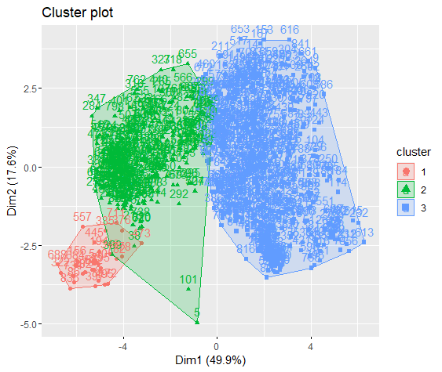

```
xxxxxxxxxx
```

```
<p>From the visualization, using three clusters may or may not be the most suitable choice. While there's observable coherence within the three clusters, there remains some overlap or interaction between distinct clusters. This indicates the need for further examination to determine the optimal cluster number for this dataset.</p>
```

From the visualization, using three clusters may or may not be the most suitable choice. While there's observable coherence within the three clusters, there remains some overlap or interaction between distinct clusters. This indicates the need for further examination to determine the optimal cluster number for this dataset.

```
xxxxxxxxxx
```

```
<h4>Visual 2</h4>
```

#### Visual 2

```
xxxxxxxxxx
```

```
# plot cluster points and lets choose 2 attribute to plot
```

```
plot(datacluster[, c("compactness","hollows_ratio")], col = (kmeanResult$cluster) )
```

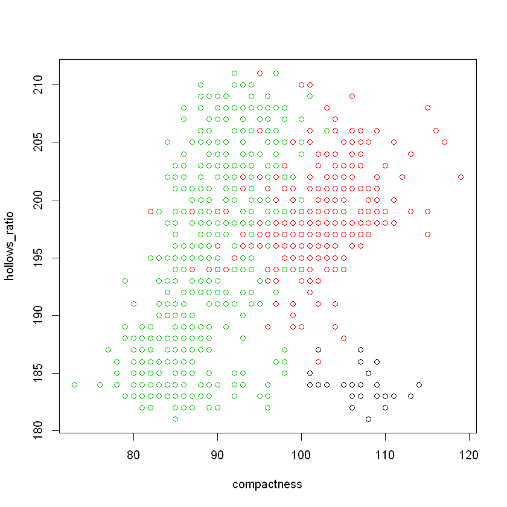

```
xxxxxxxxxx
```

```
plot(datacluster[, c("compactness", "hollows_ratio")], col = kmeanResult$cluster)
```

```
# Add cluster centers to the existing plot
```

```
points(kmeanResult$centers[, c("compactness", "hollows_ratio")], col = 1:4, pch = 8, cex = 8)
```

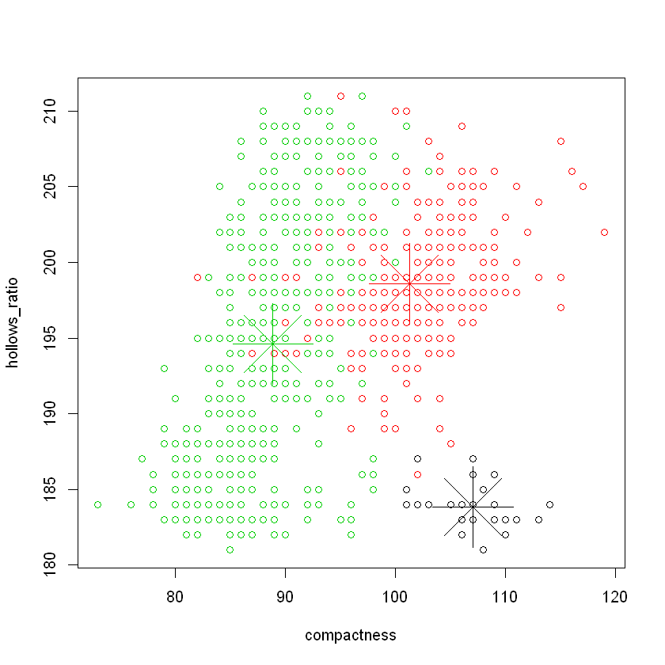

```
xxxxxxxxxx
```

```
<P>The cluster centers are accurately positioned in the middle of each respective cluster. Nevertheless, there is apparent overlap occurring between two of the clusters..</p>
```

The cluster centers are accurately positioned in the middle of each respective cluster. Nevertheless, there is apparent overlap occurring between two of the clusters..

```
xxxxxxxxxx
```

```
<h3>2.2:Kmean size 4</h3>
```

### 2.2:Kmean size 4

```
xxxxxxxxxx
```

```
##Letz now run k-mean to find 4 clusters
```

```
kmeanResult<- kmeans(datacluster,4)
```

```
xxxxxxxxxx
```

```
##Lets print the result
```

```
kmeanResult
```

```
K-means clustering with 4 clusters of sizes 253, 317, 249, 27

Cluster means:
  compactness circularity distance_circularity radius_ratio
1    92.37154    42.38340             80.05534     174.6561
2    86.95268    40.62461             67.81703     134.8233
3   102.12048    51.63454            100.14859     204.1486
4   107.03704    54.18519            102.51852     189.1852
  pr.axis_aspect_ratio max.length_aspect_ratio scatter_ratio elongatedness
1             64.74704                8.470356      160.0514      41.47826
2             57.52366                7.189274      139.9685      48.47634
3             64.46185               10.734940      206.3173      32.28112
4             56.00000                5.666667      246.0370      27.14815
  max.length_rectangularity scaled_variance scaled_variance.1
1                  142.3241        182.3399         0.2425949
```

[output cut: 110 more lines]

```
xxxxxxxxxx
```

```
The k-means result presented furnishes valuable insights, offering details such as the sizes of the four clusters, mean vectors, and components. This information serves as a foundation for conducting additional analysis.
```

The k-means result presented furnishes valuable insights, offering details such as the sizes of the four clusters, mean vectors, and components. This information serves as a foundation for conducting additional analysis.

```
xxxxxxxxxx
```

```
##Calculating total within
```

```
kmeanResult$tot.withinss
```

```
xxxxxxxxxx
```

```
<pre>[1] 847438.8
```

```
within cluster sum of square measures the sum of squared distances of each point within a cluster to the centroid of that cluster. It provides an indication of how compact the clusters are.</pre>
```

```
[1] 847438.8
within cluster sum of square measures the sum of squared distances of each point within a cluster to the centroid of that cluster. It provides an indication of how compact the clusters are.
```

```
xxxxxxxxxx
```

```
<h5>calculating precision and recall of class 1(bus)</h5>
```

##### calculating precision and recall of class 1(bus)

```
xxxxxxxxxx
```

```
##Finding bcuped precision
```

```
datacluster=bind_cols(datacluster,dataset['Class'])
```

```
#2- Find number of item in cluster
```

```
kmeanResult$size
```

```
xxxxxxxxxx
```

[output not shown]

[output not shown]

[output not shown]

```
xxxxxxxxxx
```

```
#find number of class 1 in each cluster where class 1 is bus
```

```
Clust1<-print(sum(datacluster$Class[kmeanResult$cluster =="1"]== "1", na.rm = TRUE))
```

```
xxxxxxxxxx
```

```
[1] 57
```

[1] 57

```
xxxxxxxxxx
```

[output not shown]

```
print(57*100/113)
```

```
[1] 50.44248
```

```
xxxxxxxxxx
```

```
#repeating for second cluster
```

```
Clust2<-print(sum(datacluster$Class[kmeanResult$cluster =="2"]== "1", na.rm = TRUE))
```

```
xxxxxxxxxx
```

```
[1] 97
```

[1] 97

```
xxxxxxxxxx
```

```
#97/207 97->1 in cluster and 207 is the second cluster result multiply by 100 for percentage
```

```
print(97*100/207)
```

```
[1] 46.8599
```

```
xxxxxxxxxx
```

```
## repeating for 3rd cluster
```

```
Clust3<-print(sum(datacluster$Class[kmeanResult$cluster =="3"]== "1", na.rm = TRUE))
```

```
xxxxxxxxxx
```

```
[1] 44
```

[1] 44

```
xxxxxxxxxx
```

```
#44/219 44->1 in cluster and 142 is the third cluster result multiply by 100 for percentage
```

```
print(44*100/142)
```

```
[1] 30.98592
```

```
xxxxxxxxxx
```

```
## repeating for 4th cluster
```

```
Clust4<-print(sum(datacluster$Class[kmeanResult$cluster =="4"]== "1", na.rm = TRUE))
```

```
xxxxxxxxxx
```

```
[1] 1
```

[1] 1

```
xxxxxxxxxx
```

```
#1/135 1->1 in cluster and 135 is the fourth cluster result multiply by 100 for percentage
```

```
print(1*100/135)
```

```
[1] 0.7407407
```

```
xxxxxxxxxx
```

```
#equation= #of bus in one cluster/number of all vans -> recall for class 1 (bus)
```

```
print(57*100/597)
```

```
print(97*100/597)
```

```
print(44*100/597)
```

```
print(1*100/597)
```

```
[1] 9.547739
[1] 16.24791
[1] 7.370184
[1] 0.1675042
```

```
xxxxxxxxxx
```

[output not shown]

```
xxxxxxxxxx
```

```
<h5>calculating precision and recall of class 2, we will use same size but for class 2 (car)</h5>
```

##### calculating precision and recall of class 2, we will use same size but for class 2 (car)

```
xxxxxxxxxx
```

```
#find number of class 2 in each cluster where class 2 is car
```

```
Clust1<-print(sum(datacluster$Class[kmeanResult$cluster =="1"]== "2", na.rm = TRUE))
```

```
xxxxxxxxxx
```

```
[1] 97
```

[1] 97

```
xxxxxxxxxx
```

```
#97/113=precsion formula  97->2(car) in cluster and 113 is the first cluster result
```

```
print(97*100/113)
```

```
[1] 85.84071
```

```
xxxxxxxxxx
```

```
##repeat for cluster 2
```

```
Clust2<-print(sum(datacluster$Class[kmeanResult$cluster =="2"]== "2", na.rm = TRUE))
```

```
xxxxxxxxxx
```

```
[1] 20
```

[1] 20

```
xxxxxxxxxx
```

```
#20/207 20->2 in cluster and 207 is the second cluster result
```

```
print(20*100/207)
```

```
[1] 9.661836
```

```
xxxxxxxxxx
```

```
#repeating for 3rd cluster
```

```
Clust3<-print(sum(datacluster$Class[kmeanResult$cluster =="3"]== "2", na.rm = TRUE))
```

```
xxxxxxxxxx
```

```
[1] 42
```

[1] 42

```
xxxxxxxxxx
```

```
#42/142 42->2 in cluster and 142 is the third cluster result
```

```
print(48*100/142)
```

```
[1] 33.80282
```

```
xxxxxxxxxx
```

```
## repeatinf for 4 cluster
```

```
Clust4<-print(sum(datacluster$Class[kmeanResult$cluster =="4"]== "2", na.rm = TRUE))
```

```
xxxxxxxxxx
```

```
[1] 40
```

[1] 40

```
xxxxxxxxxx
```

```
#40/135 40->2 in cluster and 135 is the fourth cluster result
```

```
print(40*100/135)
```

```
[1] 29.62963
```

```
xxxxxxxxxx
```

```
#equation= #of cars in one cluster/number of all cars -> recall for class 2 (cars)
```

```
print(97*100/597)
```

```
print(20*100/597)
```

```
print(48*100/597)
```

```
print(40*100/597)
```

```
[1] 16.24791
[1] 3.350084
[1] 8.040201
[1] 6.700168
```

```
xxxxxxxxxx
```

```
As we can see class  2(car) is mostly accupied in cluster number 1 for both precision and recall
```

As we can see class 2(car) is mostly accupied in cluster number 1 for both precision and recall

```
xxxxxxxxxx
```

```
<h5>calculating precision and recall of class 3, we will use same size but for class 3(van) </h5>
```

##### calculating precision and recall of class 3, we will use same size but for class 3(van)

```
xxxxxxxxxx
```

```
#find number of class 3 in each cluster where class 3 is van
```

```
Clust1<-print(sum(datacluster$Class[kmeanResult$cluster =="1"]== "3", na.rm = TRUE))
```

```
xxxxxxxxxx
```

```
[1] 3
```

[1] 3

```
xxxxxxxxxx
```

```
#3/113=precsion formula  3->3(van) in cluster and 113 is the first cluster result
```

```
print(3*100/113)
```

```
[1] 2.654867
```

```
xxxxxxxxxx
```

```
#repeating for second cluster
```

```
Clust2<-print(sum(datacluster$Class[kmeanResult$cluster =="2"]== "3", na.rm = TRUE))
```

```
xxxxxxxxxx
```

```
[1] 97
```

[1] 97

```
xxxxxxxxxx
```

```
#3/207=precsion formula  3->3(van) in cluster and 207 is the second cluster result
```

```
print(3*100/207)
```

```
[1] 1.449275
```

```
xxxxxxxxxx
```

```
## repeating for 3rd cluster
```

```
Clust3<-print(sum(datacluster$Class[kmeanResult$cluster =="3"]== "3", na.rm = TRUE))
```

```
xxxxxxxxxx
```

```
[1] 88
```

[1] 88

```
xxxxxxxxxx
```

```
#88/142 88->3 in cluster and 142 is the third cluster result
```

```
print(88*100/142)
```

```
[1] 61.97183
```

```
xxxxxxxxxx
```

```
## repeating for 4 cluster
```

```
Clust4<-print(sum(datacluster$Class[kmeanResult$cluster =="4"]== "3", na.rm = TRUE))
```

```
xxxxxxxxxx
```

```
[1] 11
```

[1] 11

```
xxxxxxxxxx
```

```
#11/135 11->3 in cluster and 135 is the fourth cluster result
```

```
print(11*100/135)
```

```
[1] 8.148148
```

```
xxxxxxxxxx
```

```
#equation= #of vans in one cluster/number of all vans -> recall for class 3 (vans)
```

```
print(3*100/597)
```

```
print(97*100/597)
```

```
print(88*100/597)
```

```
print(11*100/597)
```

```
[1] 0.5025126
[1] 16.24791
[1] 14.74037
[1] 1.842546
```

```
xxxxxxxxxx
```

```
As we can see (van) is mostly available im 3rd cluster accoriding to precision wheras recall second cluster.
```

As we can see (van) is mostly available im 3rd cluster accoriding to precision wheras recall second cluster.

```
xxxxxxxxxx
```

```
<h6>Visual 1</h6>
```

###### Visual 1

```
xxxxxxxxxx
```

```
fviz_cluster(kmeanResult, data = datacluster)
```

```
xxxxxxxxxx
```

```
![Rplot01.png](attachment:Rplot01.png)
```

[figure not shown]

```
xxxxxxxxxx
```

```
<p>This visual representation illustrates that opting for four clusters produced an even poorer outcome compared to three clusters. The considerable collision observed between the clusters signifies that choosing four clusters might not be a suitable option, highlighting the need for a more refined selection of 'k' for this dataset.</p>
```

This visual representation illustrates that opting for four clusters produced an even poorer outcome compared to three clusters. The considerable collision observed between the clusters signifies that choosing four clusters might not be a suitable option, highlighting the need for a more refined selection of 'k' for this dataset.

```
xxxxxxxxxx
```

```
<h6>Visual 2</h6>
```

###### Visual 2

[output not shown]

```
##lets plot but this time choose 2 different attributes than the one we chose with the 3 clusters
```

```
plot(datacluster[, c("skewness_about.1","scatter_ratio")], col = (kmeanResult$cluster) )
```

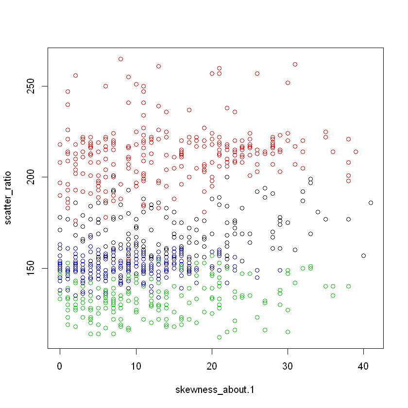

[output not shown]

```
plot(datacluster[, c("skewness_about.1", "scatter_ratio")], col = kmeanResult$cluster)
```

```
# Add cluster centers to the existing plot
```

```
points(kmeanResult$centers[, c("skewness_about.1", "scatter_ratio")], col = 1:4, pch = 8, cex = 5)
```

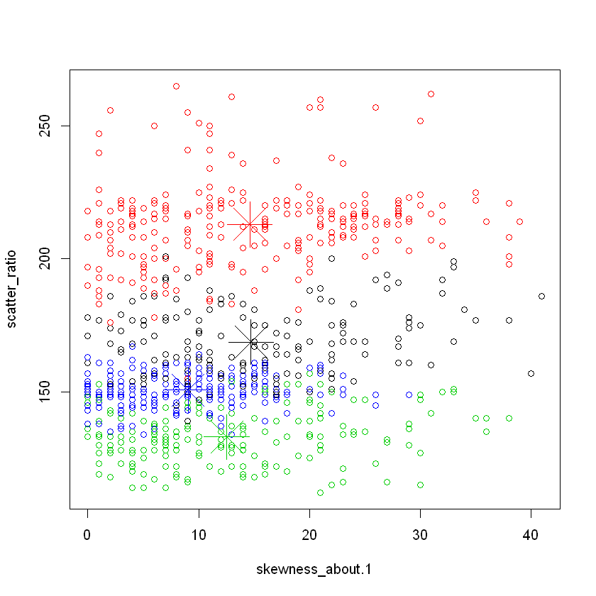

[output not shown]

[output not shown]

The second visual shows two well-distributed clusters and two with substantial overlap, implying the possibility of merging. This suggests that, upon analysis, the choice of three clusters seems more appropriate than four, offering a more accurate representation of the data.

[output not shown]

[output not shown]

### 2.3:Kmean size 2

[output not shown]

```
##Letz now run k-mean to find 2 clusters
```

```
kmeanResult<- kmeans(datacluster,2)
```

[output not shown]

```
##Lets print the result
```

```
kmeanResult
```

```
K-means clustering with 2 clusters of sizes 301, 545

Cluster means:
  compactness circularity distance_circularity radius_ratio
1   102.01329    51.33223             99.33223     202.4385
2    89.07523    41.22936             72.58349     150.3376
  pr.axis_aspect_ratio max.length_aspect_ratio scatter_ratio elongatedness
1             64.03322               10.478405      207.4718      32.23920
2             60.37615                7.511927      147.5780      45.73945
  max.length_rectangularity scaled_variance scaled_variance.1
1                  162.3455        224.3854         0.5517500
2                  140.0752        168.8312         0.1704794
  scaled_radius_of_gyration scaled_radius_of_gyration.1 skewness_about
1                  206.8970                    72.46179       7.036545
2                  156.9284                    72.43303       5.988991
```

[output cut: 100 more lines]

[output not shown]

```
The k-means result presented furnishes valuable insights, offering details such as the sizes of the two clusters, mean vectors, and components. This information serves as a foundation for conducting additional analysis.
```

The k-means result presented furnishes valuable insights, offering details such as the sizes of the two clusters, mean vectors, and components. This information serves as a foundation for conducting additional analysis.

[output not shown]

```
##Calculating total within
```

```
kmeanResult$tot.withinss
```

[output not shown]

[output not shown]

[output not shown]

```
[1] 1348687
within cluster sum of square measures the sum of squared distances of each point within a cluster to the centroid of that cluster. It provides an indication of how compact the clusters are.
```

[output not shown]

[output not shown]

##### calculating precision and recall of class 1(bus)

[output not shown]

```
##Finding bcuped precision
```

```
datacluster=bind_cols(datacluster,dataset['Class'])
```

```
#2- Find number of item in cluster
```

```
kmeanResult$size
```

[output not shown]

[output not shown]

[output not shown]

[output not shown]

[output not shown]

```
#find number of class 1 in each cluster where class 1 is bus
```

```
Clust1<-print(sum(datacluster$Class[kmeanResult$cluster =="1"]== "1", na.rm = TRUE))
```

[output not shown]

```
[1] 57
```

[1] 57

[output not shown]

[output not shown]

```
print(57*100/177)
```

```
[1] 32.20339
```

[output not shown]

```
#repeating for second cluster
```

```
Clust2<-print(sum(datacluster$Class[kmeanResult$cluster =="2"]== "1", na.rm = TRUE))
```

[output not shown]

```
[1] 142
```

[1] 142

[output not shown]

[output not shown]

```
print(142*100/142)
```

```
[1] 100
```

[output not shown]

```
#equation= #of bus in one cluster/number of all bus
```

```
print(32.20339*100/597)
```

```
print(100*100/597)
```

```
[1] 5.394203
[1] 16.75042
```

[output not shown]

```
Bus is highest in cluster 2.
```

Bus is highest in cluster 2.

[output not shown]

[output not shown]

##### calculating precision and recall of class 2, we will use same size but for class 2 (car)

[output not shown]

```
#find number of class 2 in each cluster where class 2 is car
```

```
Clust1<-print(sum(datacluster$Class[kmeanResult$cluster =="1"]== "2", na.rm = TRUE))
```

[output not shown]

```
[1] 114
```

[1] 114

[output not shown]

```
#114/177=precsion formula  114->2(car) in cluster and 177 is the first cluster result
```

```
print(114*100/177)
```

```
[1] 64.40678
```

[output not shown]

```
#repeating for second cluster
```

```
Clust2<-print(sum(datacluster$Class[kmeanResult$cluster =="2"]== "2", na.rm = TRUE))
```

[output not shown]

```
[1] 85
```

[1] 85

[output not shown]

[output not shown]

```
print(85*100/142)
```

```
[1] 59.85915
```

[output not shown]

```
#equation= #of car in one cluster/number of all car
```

```
print(114*100/597)
```

```
print(85*100/597)
```

```
[1] 19.09548
[1] 14.23786
```

[output not shown]

```
Car is higher in cluster 1.
```

Car is higher in cluster 1.

[output not shown]

[output not shown]

##### calculating precision and recall of class 3, we will use same size but for class 3(van)

[output not shown]

```
#find number of class 3 in each cluster where class 3 is van
```

```
Clust1<-print(sum(datacluster$Class[kmeanResult$cluster =="1"]== "3", na.rm = TRUE))
```

[output not shown]

```
[1] 6
```

[1] 6

[output not shown]

[output not shown]

```
print(8*100/177)
```

```
[1] 4.519774
```

[output not shown]

```
#repeating for second cluster
```

```
Clust2<-print(sum(datacluster$Class[kmeanResult$cluster =="2"]== "3", na.rm = TRUE))
```

[output not shown]

```
[1] 193
```

[1] 193

[output not shown]

[output not shown]

```
print(193*100/142)
```

```
[1] 135.9155
```

[output not shown]

```
#equation= #of van in one cluster/number of all van
```

```
print(6*100/597)
```

```
print(193*100/597)
```

```
[1] 1.005025
[1] 32.32831
```

[output not shown]

```
Van is higher in cluster 2.
```

Van is higher in cluster 2.

[output not shown]

[output not shown]

##### Visual 1

[output not shown]

```
fviz_cluster(kmeanResult, data = datacluster)
```

[output not shown]

[output not shown]

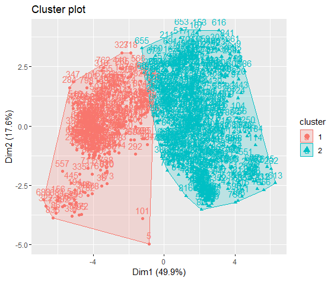

[output not shown]

[output not shown]

This visualization shows an improvement over the previous two clusters as the clustering is better grouped, with minimal observed overlap.

[output not shown]

[output not shown]